# Does Maternal Smoking Affect Infant Outcomes?

An Exploratory Data Analysis of the Birthweight Dataset

[MD Noornabi] | Mayerfeld Data Analytics Certificate

March 2026

## Background

This analysis explores a neonatal dataset of **42 babies** (20 born to non-smoking mothers, 22 to smoking mothers) to investigate whether maternal smoking is associated with differences in infant birth weight, head circumference, gestational age, and body length.

> **Note on the dataset:** Birth weights of babies born to smoking mothers have been slightly adjusted to accentuate group differences — this is an educational dataset designed for analytical practice.

## Setup

```r
library(tidyverse)
library(ggplot2)
library(moments)    # skewness, kurtosis
library(gridExtra)

# Consistent colour palette
NS_COL <- "#2ecc71"   # Non-smoker green
S_COL  <- "#e74c3c"   # Smoker red

mytheme <- theme_minimal(base_size = 13) +
  theme(plot.title    = element_text(face = "bold", size = 14),
        plot.subtitle = element_text(color = "grey40", size = 11))
```

```r
bw <- read.csv("C:/Users/Sam Fisher/Desktop/01-birthweight/data/Birthweight.csv")

bw <- bw %>% mutate(
  smoker_label = factor(smoker, levels=c(0,1), labels=c("Non-Smoker","Smoker")),
  lowbwt_label = factor(lowbwt, levels=c(0,1), labels=c("Normal","Low Birth Weight"))
)

non_smokers <- bw %>% filter(smoker == 0)
smokers     <- bw %>% filter(smoker == 1)

cat("Sample:", nrow(bw), "babies |", nrow(non_smokers), "non-smoking |", nrow(smokers), "smoking mothers")
```

```
## Sample: 42 babies | 20 non-smoking | 22 smoking mothers
```

## 1. Descriptive Statistics

### Group Summary

```r
bw %>%
  group_by(smoker_label) %>%
  summarise(
    N                  = n(),
    `Mean BW (kg)`     = round(mean(Birthweight), 3),
    `SD BW`            = round(sd(Birthweight), 3),
    `Median BW`        = round(median(Birthweight), 3),
    `Mean HC (cm)`     = round(mean(Headcirc), 3),
    `Mean Length (cm)` = round(mean(Length), 3),
    `Mean Gestation`   = round(mean(Gestation), 3),
    `% Low BW`         = paste0(round(mean(lowbwt)*100, 1), "%")
  )
```

| smoker_label | N | Mean BW (kg) | SD BW | Median BW | Mean HC (cm) | Mean Length (cm) | Mean Gestation | % Low BW |
| --- | --- | --- | --- | --- | --- | --- | --- | --- |
| Non-Smoker | 20 | 3.510 | 0.518 | 3.385 | 35.050 | 51.800 | 39.450 | 5% |
| Smoker | 22 | 3.134 | 0.631 | 3.185 | 34.182 | 50.909 | 38.955 | 22.7% |

**Key observation:** Babies of smoking mothers had a mean birth weight **0.375 kg lower** than babies of non-smoking mothers.

```r
cat("Q1.  Mean BW (non-smokers):        ", round(mean(non_smokers$Birthweight), 4), "kg\n")
```

```
## Q1.  Mean BW (non-smokers):         3.5095 kg
```

```r
cat("Q2.  Mean BW (smokers):            ", round(mean(smokers$Birthweight), 4), "kg\n")
```

```
## Q2.  Mean BW (smokers):             3.1341 kg
```

```r
cat("Q3.  Mean HC (non-smokers):        ", round(mean(non_smokers$Headcirc), 4), "cm\n")
```

```
## Q3.  Mean HC (non-smokers):         35.05 cm
```

```r
cat("Q4.  Mean gestation (smokers):     ", round(mean(smokers$Gestation), 4), "weeks\n")
```

```
## Q4.  Mean gestation (smokers):      38.9545 weeks
```

```r
cat("Q5.  Max HC (non-smokers):         ", max(non_smokers$Headcirc), "cm\n")
```

```
## Q5.  Max HC (non-smokers):          39 cm
```

```r
cat("Q6.  Min gestation (smokers):      ", min(smokers$Gestation), "weeks\n")
```

```
## Q6.  Min gestation (smokers):       33 weeks
```

```r
cat("Q9.  BW range (smokers):           ", max(smokers$Birthweight)-min(smokers$Birthweight), "kg\n")
```

```
## Q9.  BW range (smokers):            2.65 kg
```

### Birth Weight Comparison

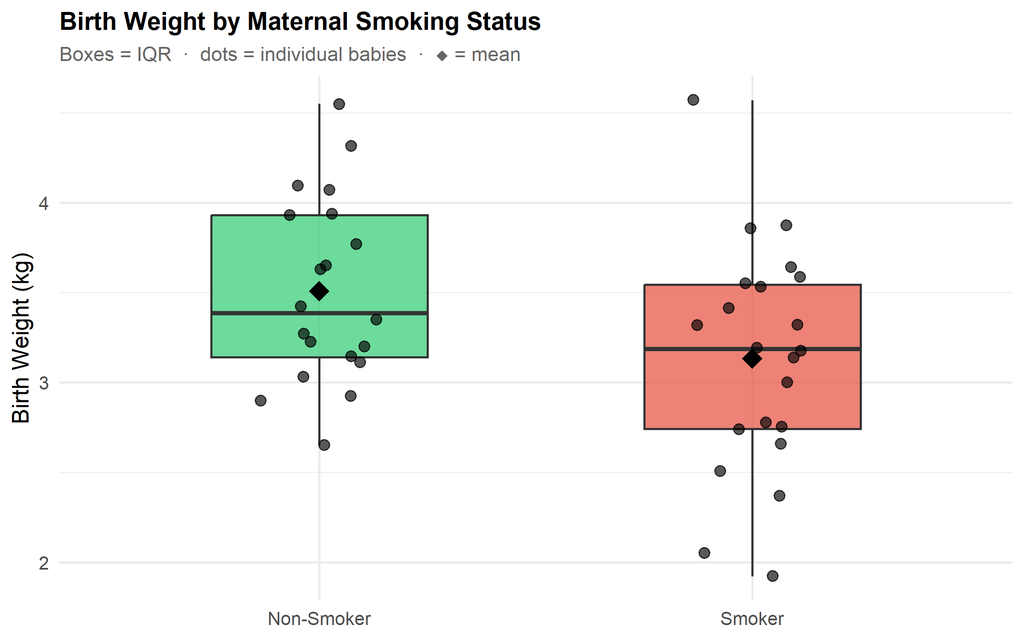

Figure 1: Individual data points overlaid on boxplots reveal the spread within each group.

```r
ggplot(bw, aes(smoker_label, Birthweight, fill=smoker_label)) +
  geom_boxplot(alpha=.7, outlier.shape=NA, width=.5) +
  geom_jitter(width=.15, alpha=.65, size=2.5) +
  stat_summary(fun=mean, geom="point", shape=18, size=5, color="black") +
  scale_fill_manual(values=c("Non-Smoker"=NS_COL,"Smoker"=S_COL)) +
  labs(title="Birth Weight by Maternal Smoking Status",
       subtitle="Boxes = IQR  ·  dots = individual babies  ·  ◆ = mean",
       x=NULL, y="Birth Weight (kg)") +
  mytheme + theme(legend.position="none")
```

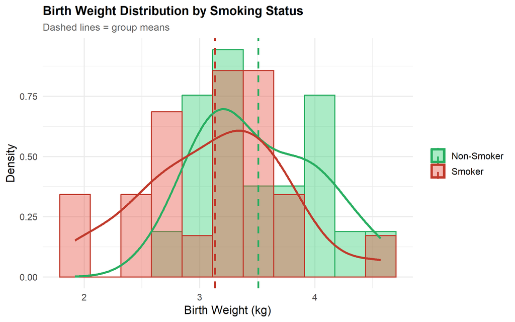

Figure 2: Overlapping density curves show the shift in the distribution for smoking mothers.

```r
means_df <- bw %>% group_by(smoker_label) %>% summarise(m=mean(Birthweight))

ggplot(bw, aes(Birthweight, fill=smoker_label, color=smoker_label)) +
  geom_histogram(aes(y=after_stat(density)), bins=11, alpha=.4, position="identity") +
  geom_density(linewidth=1.2, alpha=0) +
  geom_vline(data=means_df, aes(xintercept=m, color=smoker_label), linetype="dashed", linewidth=1) +
  scale_fill_manual(values=c("Non-Smoker"=NS_COL,"Smoker"=S_COL)) +
  scale_color_manual(values=c("Non-Smoker"="#27ae60","Smoker"="#c0392b")) +
  labs(title="Birth Weight Distribution by Smoking Status",
       subtitle="Dashed lines = group means",
       x="Birth Weight (kg)", y="Density", fill=NULL, color=NULL) +
  mytheme
```

## 2. Normality Testing

```r
check_normality <- function(x, label) {
  sw <- shapiro.test(x)
  tibble(
    Variable    = label,
    W           = round(sw$statistic, 4),
    `p-value`   = round(sw$p.value, 4),
    Skewness    = round(skewness(x), 3),
    Kurtosis    = round(kurtosis(x), 3),
    Result      = ifelse(sw$p.value > 0.05, "Normal ✓", "Not Normal ✗")
  )
}
```

```r
bind_rows(
  check_normality(smokers$Headcirc,       "Head circumference — Smokers      (Q11/12)"),
  check_normality(non_smokers$Birthweight,"Birth weight — Non-Smokers         (Q14)"),
  check_normality(smokers$Birthweight,    "Birth weight — Smokers            (Q15/16)"),
  check_normality(non_smokers$Length,     "Baby length — Non-Smokers         (Q19/20)")
)
```

| Variable | W | p-value | Skewness | Kurtosis | Result |
| --- | --- | --- | --- | --- | --- |
| Head circumference — Smokers (Q11/12) | 0.9537 | 0.3724 | 0.087 | 2.174 | Normal ✓ |
| Birth weight — Non-Smokers (Q14) | 0.9673 | 0.6962 | 0.333 | 2.157 | Normal ✓ |
| Birth weight — Smokers (Q15/16) | 0.9824 | 0.9495 | 0.021 | 2.876 | Normal ✓ |
| Baby length — Non-Smokers (Q19/20) | 0.9123 | 0.0704 | -0.795 | 4.192 | Normal ✓ |

**Q14:** Birth weight in non-smoking mothers has a skewness of 0.3334 → **positively skewed** (right tail).

### Q-Q Plots

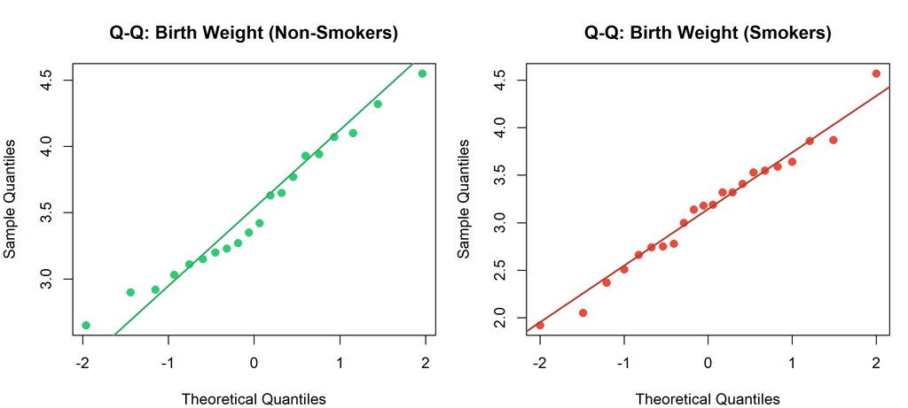

Figure 3: Points close to the diagonal line indicate normality. Both groups follow the line reasonably well.

```r
par(mfrow=c(1,2), mar=c(4,4,3.5,1))
qqnorm(non_smokers$Birthweight, main="Q-Q: Birth Weight (Non-Smokers)",
       col=NS_COL, pch=16, cex=1.2); qqline(non_smokers$Birthweight, col="#27ae60", lwd=2)
qqnorm(smokers$Birthweight, main="Q-Q: Birth Weight (Smokers)",
       col=S_COL, pch=16, cex=1.2); qqline(smokers$Birthweight, col="#c0392b", lwd=2)
```

## 3. Z-Scores & Probability

```r
mean_hc_ns  <- mean(non_smokers$Headcirc);  sd_hc_ns  <- sd(non_smokers$Headcirc)
mean_bw_s   <- mean(smokers$Birthweight);   sd_bw_s   <- sd(smokers$Birthweight)
mean_len_ns <- mean(non_smokers$Length);    sd_len_ns <- sd(non_smokers$Length)
mean_bw_all <- mean(bw$Birthweight);        sd_bw_all <- sd(bw$Birthweight)

z13  <- (35.05 - mean_hc_ns) / sd_hc_ns
z18  <- (4.2   - mean_bw_s)  / sd_bw_s
z21  <- (48.5  - mean_len_ns)/ sd_len_ns
z22  <- (55    - mean_len_ns)/ sd_len_ns

tibble(
  Question = c("Q13: Z for HC=35.05 (non-smokers)",
               "Q17: +/- 1SD range (all babies)",
               "Q18: P(BW < 4.2 kg | smokers)",
               "Q21: Z for length=48.5 (non-smokers)",
               "Q22: P(length > 55 cm | non-smokers)"),
  Answer = c(
    paste("Z =", round(z13, 4), "[35.05 = mean, so Z = 0]"),
    paste0("[", round(mean_bw_all - sd_bw_all, 3), ", ", round(mean_bw_all + sd_bw_all, 3), "] kg  (~68% confidence)"),
    paste0("Z = ", round(z18, 4), "  →  p = ", round(pnorm(z18)*100, 2), "%"),
    paste("Z =", round(z21, 4)),
    paste0("Z = ", round(z22, 4), "  →  p = ", round((1-pnorm(z22))*100, 2), "%")
  )
)
```

| Question | Answer |
| --- | --- |
| Q13: Z for HC=35.05 (non-smokers) | Z = 0 [35.05 = mean, so Z = 0] |
| Q17: +/- 1SD range (all babies) | [2.709, 3.917] kg (~68% confidence) |
| Q18: P(BW < 4.2 kg \| smokers) | Z = 1.6886 → p = 95.43% |
| Q21: Z for length=48.5 (non-smokers) | Z = -1.0141 |
| Q22: P(length > 55 cm \| non-smokers) | Z = 0.9834 → p = 16.27% |

## 4. Extended Analysis

### 4A. Are Group Differences Statistically Significant?

Going beyond descriptive statistics, Welch’s independent samples t-test checks whether the observed differences are likely to reflect a real effect or just sampling variation.

```r
cohens_d <- function(x, y) (mean(x) - mean(y)) / sqrt((sd(x)^2 + sd(y)^2) / 2)

outcomes <- list(
  list(v="Birthweight", label="Birth weight (kg)"),
  list(v="Headcirc",    label="Head circumference (cm)"),
  list(v="Gestation",   label="Gestational age (weeks)"),
  list(v="Length",      label="Baby length (cm)")
)

map_dfr(outcomes, function(o) {
  ns <- non_smokers[[o$v]]; s <- smokers[[o$v]]
  tt <- t.test(ns, s, var.equal=FALSE)
  d  <- cohens_d(ns, s)
  tibble(
    Outcome         = o$label,
    `Mean (NS)`     = round(mean(ns), 3),
    `Mean (S)`      = round(mean(s), 3),
    `Difference`    = round(mean(ns)-mean(s), 3),
    `t-stat`        = round(tt$statistic, 3),
    `p-value`       = round(tt$p.value, 4),
    Significant     = ifelse(tt$p.value < 0.05, "Yes **", "No"),
    `Cohen's d`     = round(d, 3),
    `Effect Size`   = ifelse(abs(d)>=0.8,"Large",ifelse(abs(d)>=0.5,"Medium","Small"))
  )
})
```

| Outcome | Mean (NS) | Mean (S) | Difference | t-stat | p-value | Significant | Cohen's d | Effect Size |
| --- | --- | --- | --- | --- | --- | --- | --- | --- |
| Birth weight (kg) | 3.51 | 3.134 | 0.375 | 2.113 | 0.0409 | Yes ** | 0.650 | Medium |
| Head circumference (cm) | 35.05 | 34.182 | 0.868 | 1.189 | 0.2414 | No | 0.366 | Small |
| Gestational age (weeks) | 39.45 | 38.955 | 0.495 | 0.599 | 0.5527 | No | 0.186 | Small |
| Baby length (cm) | 51.80 | 50.909 | 0.891 | 0.972 | 0.3376 | No | 0.302 | Small |

### 4B. Dose-Response: Does Smoking More = Lower Birth Weight?

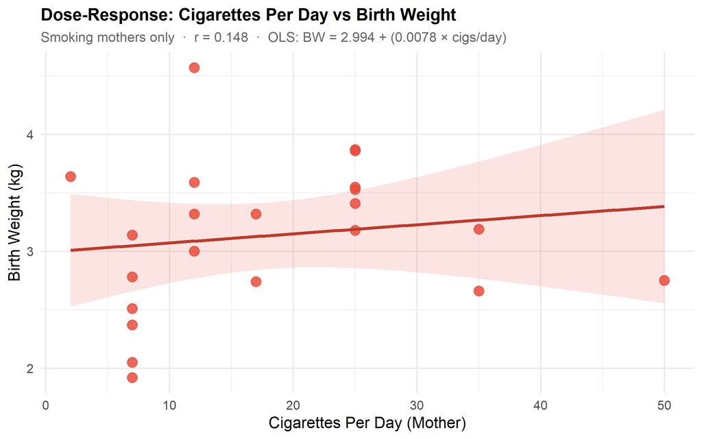

```r
lm_dose <- lm(Birthweight ~ mnocig, data=smokers)
r_dose  <- cor(smokers$mnocig, smokers$Birthweight)

ggplot(smokers, aes(mnocig, Birthweight)) +
  geom_point(color=S_COL, size=3.5, alpha=.85) +
  geom_smooth(method="lm", se=TRUE, color="#c0392b", fill=S_COL, alpha=.15) +
  labs(title="Dose-Response: Cigarettes Per Day vs Birth Weight",
       subtitle=paste0("Smoking mothers only  ·  r = ", round(r_dose,3),
                       "  ·  OLS: BW = ", round(coef(lm_dose)[1],3),
                       " + (", round(coef(lm_dose)[2],4), " × cigs/day)"),
       x="Cigarettes Per Day (Mother)", y="Birth Weight (kg)") +
  mytheme
```

```r
summary(lm_dose)
```

```
##
## Call:
## lm(formula = Birthweight ~ mnocig, data = smokers)
##
## Residuals:
##      Min       1Q   Median       3Q      Max
## -1.12824 -0.50025  0.04152  0.35628  1.48273
##
## Coefficients:
##             Estimate Std. Error t value Pr(>|t|)
## (Intercept) 2.993615   0.249882  11.980  1.4e-10 ***
## mnocig      0.007804   0.011632   0.671     0.51
## ---
## Signif. codes:  0 '***' 0.001 '**' 0.01 '*' 0.05 '.' 0.1 ' ' 1
##
## Residual standard error: 0.6397 on 20 degrees of freedom
## Multiple R-squared:  0.02201,    Adjusted R-squared:  -0.02689
## F-statistic: 0.4501 on 1 and 20 DF,  p-value: 0.51
```

### 4C. Low Birth Weight Risk

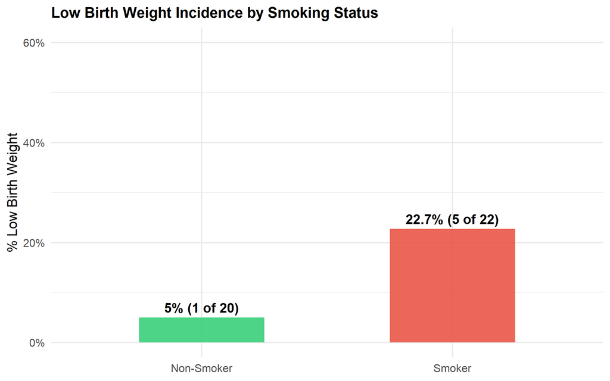

Figure 7: Smoking mothers had a markedly higher proportion of low birth weight babies.

```r
lowbwt_plot <- bw %>% group_by(smoker_label) %>%
  summarise(pct=mean(lowbwt)*100, n=n(), n_low=sum(lowbwt))

ggplot(lowbwt_plot, aes(smoker_label, pct, fill=smoker_label)) +
  geom_col(width=.5, alpha=.85) +
  geom_text(aes(label=paste0(round(pct,1),"% (", n_low, " of ", n, ")")),
            vjust=-0.5, size=4.5, fontface="bold") +
  scale_fill_manual(values=c("Non-Smoker"=NS_COL,"Smoker"=S_COL)) +
  scale_y_continuous(limits=c(0,60), labels=function(x) paste0(x,"%")) +
  labs(title="Low Birth Weight Incidence by Smoking Status",
       x=NULL, y="% Low Birth Weight") +
  mytheme + theme(legend.position="none")
```

```r
chi_res <- chisq.test(table(bw$smoker, bw$lowbwt), correct=FALSE)
cat("Chi-square:", round(chi_res$statistic, 4), "  p =", round(chi_res$p.value, 4))
```

```
## Chi-square: 2.6886   p = 0.1011
```

### 4D. All Outcomes — Side-by-Side

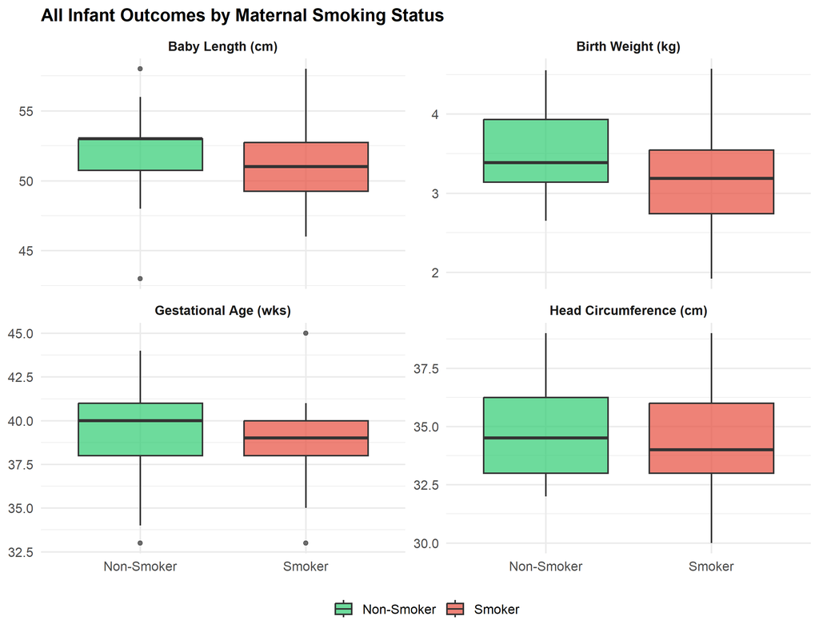

Figure 8: Consistent pattern across all four infant outcomes — smoking group shows lower/shorter values.

```r
bw %>%
  select(smoker_label, Birthweight, Headcirc, Length, Gestation) %>%
  pivot_longer(-smoker_label, names_to="Outcome", values_to="Value") %>%
  mutate(Outcome=recode(Outcome,
    "Birthweight"="Birth Weight (kg)", "Headcirc"="Head Circumference (cm)",
    "Length"="Baby Length (cm)", "Gestation"="Gestational Age (wks)")) %>%
  ggplot(aes(smoker_label, Value, fill=smoker_label)) +
  geom_boxplot(alpha=.7, outlier.size=1.5) +
  facet_wrap(~Outcome, scales="free_y", ncol=2) +
  scale_fill_manual(values=c("Non-Smoker"=NS_COL,"Smoker"=S_COL)) +
  labs(title="All Infant Outcomes by Maternal Smoking Status",
       x=NULL, y=NULL, fill=NULL) +
  mytheme + theme(strip.text=element_text(face="bold"), legend.position="bottom")
```

### 4E. Correlation Analysis

```r
bw %>%
  select(Birthweight, Length, Headcirc, Gestation, mnocig, mheight, mppwt) %>%
  cor(use="complete.obs") %>%
  round(3)
```

```
##             Birthweight Length Headcirc Gestation mnocig mheight mppwt
## Birthweight       1.000  0.727    0.685     0.708 -0.152   0.363 0.401
## Length            0.727  1.000    0.563     0.705 -0.040   0.485 0.398
## Headcirc          0.685  0.563    1.000     0.405 -0.133   0.337 0.303
## Gestation         0.708  0.705    0.405     1.000  0.043   0.211 0.255
## mnocig           -0.152 -0.040   -0.133     0.043  1.000   0.126 0.149
## mheight           0.363  0.485    0.337     0.211  0.126   1.000 0.681
## mppwt             0.401  0.398    0.303     0.255  0.149   0.681 1.000
```

## 5. Summary & Conclusions

[output not shown]

**Caveat:** This is a small sample (n=42) and the birth weights were slightly adjusted for educational purposes. Findings should be interpreted as illustrative of analytical method rather than definitive clinical evidence.

*Analysis conducted in R as part of the Mayerfeld Data Analytics Certificate — Week 1.*  
*Tools: R, tidyverse, ggplot2, moments*